# Correlation between ex situ Flowering time and Dormancy

Justine Floret

2025-09-29

```r
library(readr)
library(dplyr)
library(tidyr)
library(data.table)
library(gtable)
library(ggplot2)
library(ggrepel)
library(gdata) # cbind data set with different number of rows
# Graphic library
library(RColorBrewer)
library(forcats) # reorganize in geom boxplot
library(patchwork)
library(viridis)
library(svglite) # save in svg format
library(lemon)
library(ggridges) # ridge density plot
library(geomtextpath) # correlation with multiple group
library(lmerTest) #glht
library(lsmeans) #pairwise comparison
library(multcomp)  #glht
library(multcompView)  #glht
library(MASS) # glm.nb
library(glmmTMB) # negative binomial
library(rstatix)
```

```r
colors <- c("#6ece58", "#22a884", "#355f8d", "#440154")
```

In February-March 2025 populations of A. thaliana were sampled and transplanted in the greenhouse at the University of Cologne. The seeds of each individuals have been harvested, and germinated to measure the flowering time and the dormancy in controlled conditions

# 1. F2 Phenotypes

## Importing the data set

```r
#  - Floret, Justine (jfloret@uni-koeln.de)@uni-koeln.sciebo.de
F2_dormancy_df <- read_delim("/home/justine/sciebo/3_Exsitu_phenotype/Flowering_time/assay/F2_FT_dormancy_CC/Data/Dormancy_group2.csv", delim=";")
F2_dormancy_df$date_of_ripening <- as.Date(paste0(F2_dormancy_df$date_of_ripening, "/2024"), format = "%d/%m/%Y")
F2_dormancy_df$W2_growth_chamber <- as.Date(paste0(F2_dormancy_df$W2_growth_chamber, "/2024"), format = "%d/%m/%Y")
F2_dormancy_df$W2_counting <- as.Date(paste0(F2_dormancy_df$W2_counting, "/2024"), format = "%d/%m/%Y")
F2_dormancy_df$W3_growth_chamber <- as.Date(paste0(F2_dormancy_df$W3_growth_chamber, "/2024"), format = "%d/%m/%Y")
F2_dormancy_df$W3_counting <- as.Date(paste0(F2_dormancy_df$W3_counting, "/2024"), format = "%d/%m/%Y")
F2_dormancy_df$W4_growth_chamber <- as.Date(paste0(F2_dormancy_df$W4_growth_chamber, "/2024"), format = "%d/%m/%Y")
F2_dormancy_df$W4_counting <- as.Date(paste0(F2_dormancy_df$W4_counting, "/2024"), format = "%d/%m/%Y")
F2_dormancy_df$W6_growth_chamber <- as.Date(paste0(F2_dormancy_df$W6_growth_chamber, "/2024"), format = "%d/%m/%Y")
F2_dormancy_df$W6_counting <- as.Date(paste0(F2_dormancy_df$W6_counting, "/2024"), format = "%d/%m/%Y")
F2_dormancy_df$plant_number <- as.factor(F2_dormancy_df$plant_number)
F2_dormancy_df <- F2_dormancy_df[1:359,1:18]
```

Adding the data of the beginning of the long day treatment : March 1st

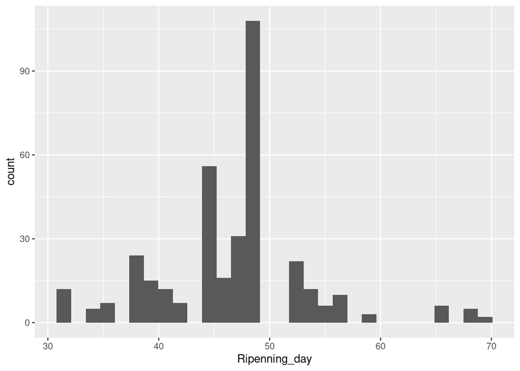

```r
F2_dormancy_df$LD_beginning <-  as.Date("01/03/2024", format = "%d/%m/%Y")
F2_dormancy_df$Ripenning_day <- as.integer(F2_dormancy_df$date_of_ripening - F2_dormancy_df$LD_beginning)
ggplot(F2_dormancy_df, aes(x = Ripenning_day)) + geom_histogram()
```

Formatting the dormancy data set

```r
F2_dormancy_df <- F2_dormancy_df[,c(1,5,6,9,10,13,14,17,18,20)]
F2_dormancy_df <- F2_dormancy_df %>% replace(.,is.na(.),0)

F2_dormancy_df <- F2_dormancy_df %>%
  pivot_longer(
    cols = -c(plant_number,Ripenning_day),
    names_to = c("Week", ".value"),
    names_pattern = "W(\\d+)_(.*)"
  ) %>%
  rename(
    Plant_ID = plant_number,
    Tot_seed = totseeds,
    Tot_germinated = seed_germinated
  )
```

## Model

```r
F2_dormancy_df$Ripenning_day <- as.numeric(F2_dormancy_df$Ripenning_day)
F2_dormancy_df$Tot_seed <- as.numeric(F2_dormancy_df$Tot_seed)
F2_dormancy_df$Tot_germinated <- as.numeric(F2_dormancy_df$Tot_germinated)
F2_dormancy_df$Plant_ID <- as.factor(F2_dormancy_df$Plant_ID)
F2_dormancy_df$Week <- as.numeric(F2_dormancy_df$Week)
```

```r
F2_dormancy_df <- F2_dormancy_df %>% filter(Tot_seed>0)
F2_dormancy_df <- F2_dormancy_df %>% filter(Week != 3)

glm_model <- glm( cbind(Tot_germinated, Tot_seed -Tot_germinated ) ~ Ripenning_day+Week, data  = F2_dormancy_df,family = quasibinomial())
summary(glm_model)
```

```
##
## Call:
## glm(formula = cbind(Tot_germinated, Tot_seed - Tot_germinated) ~
##     Ripenning_day + Week, family = quasibinomial(), data = F2_dormancy_df)
##
## Coefficients:
##               Estimate Std. Error t value Pr(>|t|)
## (Intercept)   -2.48772    0.58630  -4.243 2.42e-05 ***
## Ripenning_day -0.02389    0.01168  -2.046    0.041 *
## Week           0.41916    0.04916   8.526  < 2e-16 ***
## ---
## Signif. codes:  0 '***' 0.001 '**' 0.01 '*' 0.05 '.' 0.1 ' ' 1
##
## (Dispersion parameter for quasibinomial family taken to be 15.43619)
##
##     Null deviance: 14653  on 973  degrees of freedom
## Residual deviance: 13321  on 971  degrees of freedom
## AIC: NA
##
## Number of Fisher Scoring iterations: 4
```

```r
Anova(glm_model, type='II')
```

```
## Analysis of Deviance Table (Type II tests)
##
## Response: cbind(Tot_germinated, Tot_seed - Tot_germinated)
##               LR Chisq Df Pr(>Chisq)
## Ripenning_day    4.268  1    0.03883 *
## Week            82.039  1    < 2e-16 ***
## ---
## Signif. codes:  0 '***' 0.001 '**' 0.01 '*' 0.05 '.' 0.1 ' ' 1
```

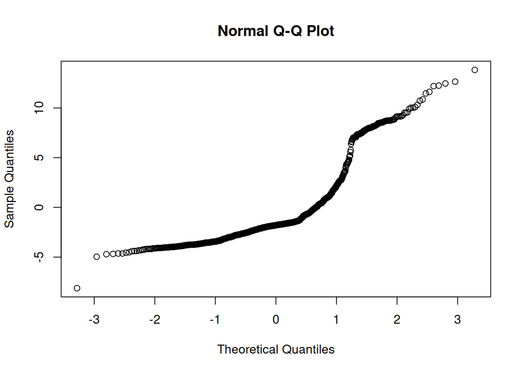

```r
qqnorm(resid(glm_model))
```

```r
glm_model2 <- glm( cbind(Tot_germinated, Tot_seed -Tot_germinated ) ~ Week, data  = F2_dormancy_df,family = quasibinomial())
summary(glm_model2)
```

```
##
## Call:
## glm(formula = cbind(Tot_germinated, Tot_seed - Tot_germinated) ~
##     Week, family = quasibinomial(), data = F2_dormancy_df)
##
## Coefficients:
##             Estimate Std. Error t value Pr(>|t|)
## (Intercept) -3.58820    0.24565 -14.607   <2e-16 ***
## Week         0.41840    0.04956   8.442   <2e-16 ***
## ---
## Signif. codes:  0 '***' 0.001 '**' 0.01 '*' 0.05 '.' 0.1 ' ' 1
##
## (Dispersion parameter for quasibinomial family taken to be 15.73795)
##
##     Null deviance: 14653  on 973  degrees of freedom
## Residual deviance: 13387  on 972  degrees of freedom
## AIC: NA
##
## Number of Fisher Scoring iterations: 4
```

```r
Anova(glm_model2, type='II')
```

```
## Analysis of Deviance Table (Type II tests)
##
## Response: cbind(Tot_germinated, Tot_seed - Tot_germinated)
##      LR Chisq Df Pr(>Chisq)
## Week    80.43  1  < 2.2e-16 ***
## ---
## Signif. codes:  0 '***' 0.001 '**' 0.01 '*' 0.05 '.' 0.1 ' ' 1
```

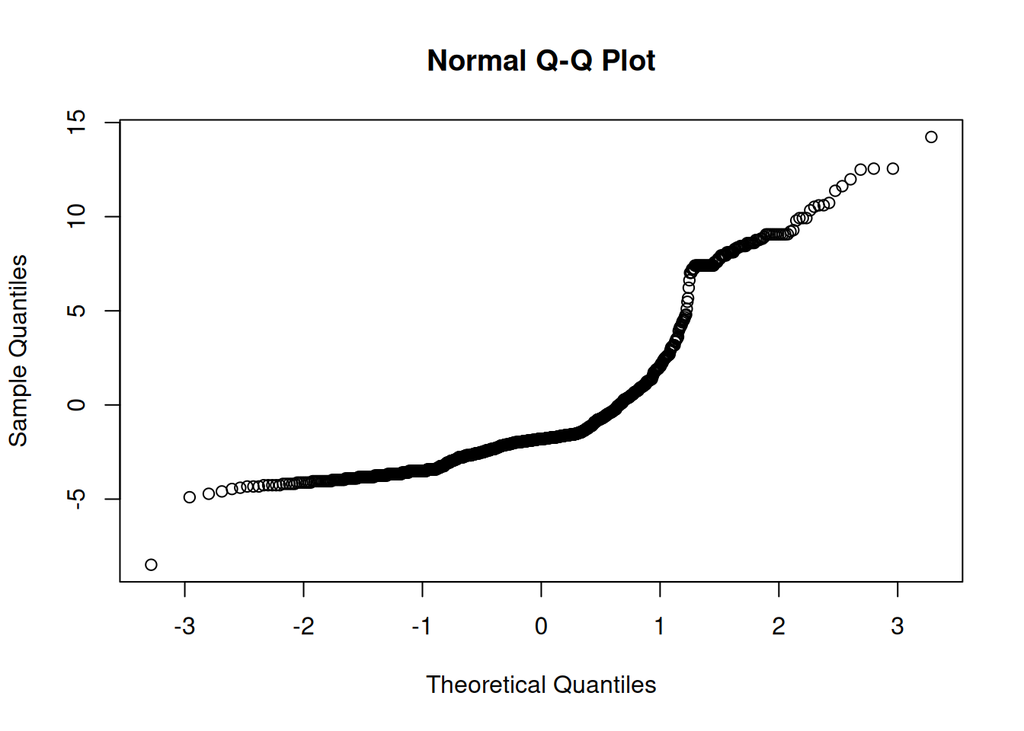

```r
qqnorm(resid(glm_model2))
```

```r
glm_model3 <- glm( cbind(Tot_germinated, Tot_seed -Tot_germinated ) ~ Week/Plant_ID + Ripenning_day, data  = F2_dormancy_df,family = quasibinomial())
summary(glm_model3)
```

```
##
## Call:
## glm(formula = cbind(Tot_germinated, Tot_seed - Tot_germinated) ~
##     Week/Plant_ID + Ripenning_day, family = quasibinomial(),
##     data = F2_dormancy_df)
##
## Coefficients:
##                    Estimate Std. Error t value Pr(>|t|)
## (Intercept)      -2.066e+01  2.635e+00  -7.840 2.01e-14 ***
## Week              1.527e+00  2.438e-01   6.261 7.17e-10 ***
## Ripenning_day     3.316e-01  5.414e-02   6.125 1.62e-09 ***
## Week:Plant_ID2   -4.472e+00  3.542e+03  -0.001 0.998993
## Week:Plant_ID3   -4.463e+00  3.557e+03  -0.001 0.998999
## Week:Plant_ID4   -2.316e-01  3.202e-01  -0.723 0.469750
## Week:Plant_ID5   -2.165e-01  2.927e-01  -0.740 0.459786
## Week:Plant_ID6   -4.533e+00  3.521e+03  -0.001 0.998973
## Week:Plant_ID7   -2.311e-01  3.201e-01  -0.722 0.470605
## Week:Plant_ID8    6.189e-01  2.887e-01   2.144 0.032457 *
## Week:Plant_ID9   -1.256e-01  2.729e-01  -0.460 0.645420
## Week:Plant_ID10   5.145e-02  2.354e-01   0.219 0.827068
## Week:Plant_ID11  -3.655e-02  2.400e-01  -0.152 0.878986
## Week:Plant_ID12  -4.441e+00  3.555e+03  -0.001 0.999004
## Week:Plant_ID13   4.492e-01  2.717e-01   1.653 0.098755 .
## Week:Plant_ID14   5.895e+00  2.346e+03   0.003 0.997996
## Week:Plant_ID15   9.026e-01  3.135e-01   2.879 0.004129 **
## Week:Plant_ID16  -4.607e+00  3.559e+03  -0.001 0.998968
## Week:Plant_ID17  -4.595e+00  3.562e+03  -0.001 0.998971
## Week:Plant_ID18  -1.685e-01  2.443e-01  -0.690 0.490573
## Week:Plant_ID19  -1.479e-01  2.396e-01  -0.617 0.537147
## Week:Plant_ID20   5.874e+00  2.231e+03   0.003 0.997900
## Week:Plant_ID21  -4.370e-01  3.193e-01  -1.368 0.171706
## Week:Plant_ID22   3.164e-01  2.556e-01   1.238 0.216185
## Week:Plant_ID23  -2.090e-01  2.598e-01  -0.805 0.421382
## Week:Plant_ID24  -7.254e-02  2.362e-01  -0.307 0.758884
## Week:Plant_ID25  -4.429e-01  2.873e-01  -1.541 0.123750
## Week:Plant_ID26  -7.896e+00  3.997e+03  -0.002 0.998424
## Week:Plant_ID27  -7.954e-01  4.812e-01  -1.653 0.098829 .
## Week:Plant_ID28   2.475e+00  4.178e-01   5.925 5.22e-09 ***
## Week:Plant_ID29  -8.108e+00  3.962e+03  -0.002 0.998368
## Week:Plant_ID30  -4.364e-01  2.502e-01  -1.745 0.081572 .
```

[output cut: 324 more lines]

```
## Week:Plant_ID355 -1.279e+01  3.436e+03  -0.004 0.997032
## Week:Plant_ID356 -1.279e+01  3.451e+03  -0.004 0.997043
## Week:Plant_ID357 -1.251e+01  3.738e+03  -0.003 0.997331
## Week:Plant_ID358 -1.302e+01  3.388e+03  -0.004 0.996936
## Week:Plant_ID359 -1.306e+01  3.248e+03  -0.004 0.996792
## ---
## Signif. codes:  0 '***' 0.001 '**' 0.01 '*' 0.05 '.' 0.1 ' ' 1
##
## (Dispersion parameter for quasibinomial family taken to be 4.364174)
##
##     Null deviance: 14653  on 973  degrees of freedom
## Residual deviance:  2365  on 613  degrees of freedom
## AIC: NA
##
## Number of Fisher Scoring iterations: 19
```

```r
Anova(glm_model3, type='II')
```

```
## Analysis of Deviance Table (Type II tests)
##
## Response: cbind(Tot_germinated, Tot_seed - Tot_germinated)
##               LR Chisq  Df Pr(>Chisq)
## Week            290.17   1  < 2.2e-16 ***
## Ripenning_day    41.87   1  9.738e-11 ***
## Week:Plant_ID  2510.45 358  < 2.2e-16 ***
## ---
## Signif. codes:  0 '***' 0.001 '**' 0.01 '*' 0.05 '.' 0.1 ' ' 1
```

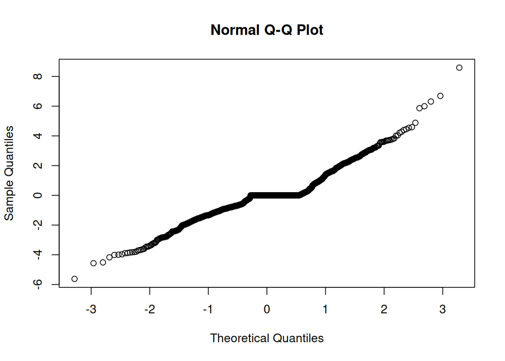

```r
qqnorm(resid(glm_model3))
```

```r
anova(glm_model2, glm_model, glm_model3)
```

```
## Analysis of Deviance Table
##
## Model 1: cbind(Tot_germinated, Tot_seed - Tot_germinated) ~ Week
## Model 2: cbind(Tot_germinated, Tot_seed - Tot_germinated) ~ Ripenning_day +
##     Week
## Model 3: cbind(Tot_germinated, Tot_seed - Tot_germinated) ~ Week/Plant_ID +
##     Ripenning_day
##   Resid. Df Resid. Dev  Df Deviance       F    Pr(>F)
## 1       972      13387
## 2       971      13321   1     65.9 15.0971 0.0001132 ***
## 3       613       2365 358  10956.0  7.0124 < 2.2e-16 ***
## ---
## Signif. codes:  0 '***' 0.001 '**' 0.01 '*' 0.05 '.' 0.1 ' ' 1
```

Correlation test

```r
cor.test(F2_dormancy_df$Ripenning_day, (F2_dormancy_df$Tot_germinated - F2_dormancy_df$Tot_seed),  method = "spearman")
```

```
##
##  Spearman's rank correlation rho
##
## data:  F2_dormancy_df$Ripenning_day and (F2_dormancy_df$Tot_germinated - F2_dormancy_df$Tot_seed)
## S = 147954671, p-value = 0.2208
## alternative hypothesis: true rho is not equal to 0
## sample estimates:
##        rho
## 0.03926521
```

## Graph

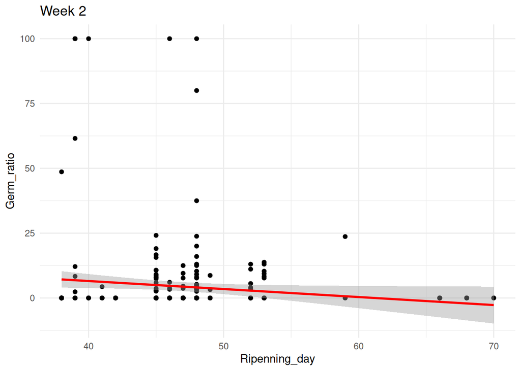

```r
F2_dormancy_df$Germ_ratio <- F2_dormancy_df$Tot_germinated/ F2_dormancy_df$Tot_seed *100
F2_dormancy_df$Germ_ratio <- round(F2_dormancy_df$Germ_ratio,2)
F2_dormancy_df %>% filter(Week == 2) %>%
  ggplot(aes(x=Ripenning_day, y=Germ_ratio)) +
  geom_point() +
  geom_smooth(method=lm , color="red", se=TRUE) +
  labs(title = "Week 2")+theme_minimal()
```

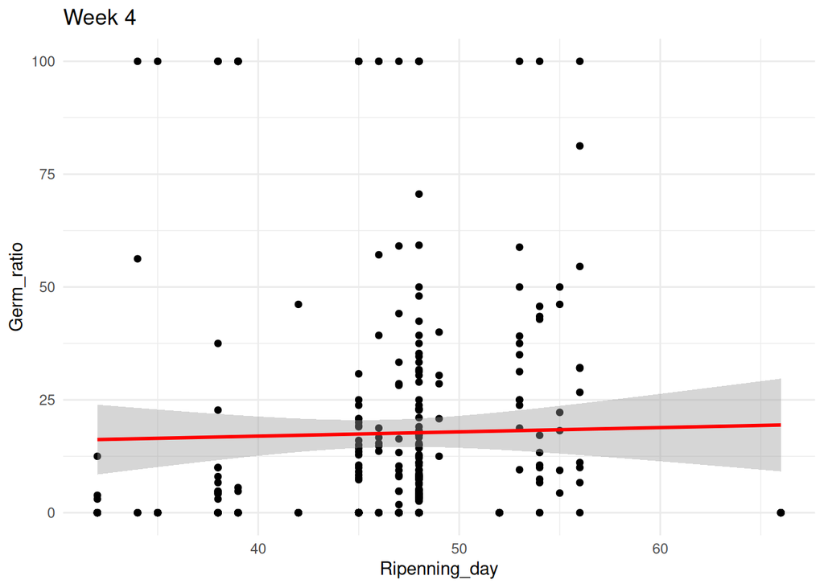

```r
F2_dormancy_df %>% filter(Week == 4) %>%
  ggplot(aes(x=Ripenning_day, y=Germ_ratio)) +
  geom_point() +
  geom_smooth(method=lm , color="red", se=TRUE) +
  labs(title = "Week 4")+theme_minimal()
```

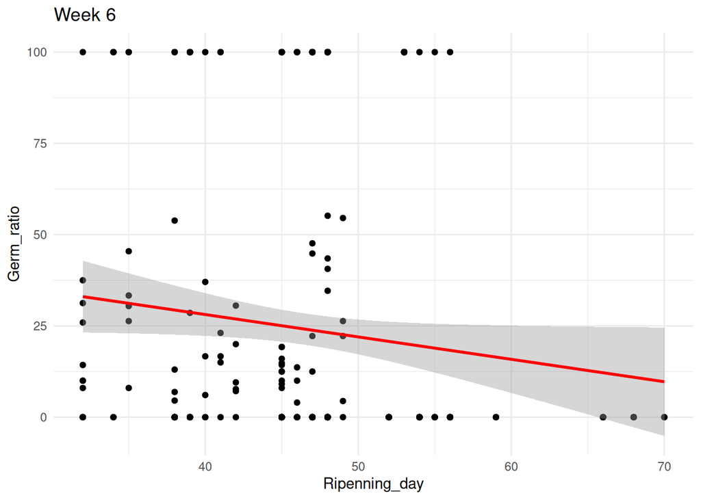

```r
F2_dormancy_df %>% filter(Week == 6) %>%
  ggplot(aes(x=Ripenning_day, y=Germ_ratio)) +
  geom_point() +
  geom_smooth(method=lm , color="red", se=TRUE) +
  labs(title = "Week 6")+
  theme_minimal()
```

```r
F2_dormancy_df_W6 <- F2_dormancy_df %>% filter(Week == 6)
cor.test(F2_dormancy_df_W6$Ripenning_day, F2_dormancy_df_W6$Germ_ratio,  method = "spearman")
```

```
##
##  Spearman's rank correlation rho
##
## data:  F2_dormancy_df_W6$Ripenning_day and F2_dormancy_df_W6$Germ_ratio
## S = 7413333, p-value = 0.0003677
## alternative hypothesis: true rho is not equal to 0
## sample estimates:
##        rho
## -0.1937935
```

# 2. Ex situ FT 2025, seeds from transplanted individuals (Lee)

## 1. Importing the data set

```r
# Uni directory:  - Floret, Justine (jfloret@uni-koeln.de)@uni-koeln.sciebo.de
data_FT_F6 <- read_csv("/home/justine/sciebo/3_Exsitu_phenotype/Flowering_time/assay/F6_tplant_FT_2025.csv")
data_FT_F6$ID_F5_parent <- as.factor(data_FT_F6$ID_F5_parent)
data_FT_F6$Pop <- as.factor(data_FT_F6$Pop)
data_FT_F6 <- data_FT_F6 %>% dplyr::mutate(Comments= replace_na(Comments, "Alive"))
data_FT_F6$Comments <- as.factor(data_FT_F6$Comments)
data_FT_F6$Tray <- as.factor(data_FT_F6$Tray)
data_FT_F6 <- data_FT_F6 %>% filter(Comments == "Alive")
```

Ensure date columns are Date type

```r
data_FT_F6$brought_to_greenhouse <- as.Date(data_FT_F6$brought_to_greenhouse, format = "%Y/%m/%d")
data_FT_F6$FT <- as.Date(data_FT_F6$FT , format = "%m/%d/%y")
```

```r
data_FT_F6$FT_day <- as.integer(data_FT_F6$FT - data_FT_F6$brought_to_greenhouse)
data_FT_F6$FT_day <- as.numeric(data_FT_F6$FT_day)
```

Adding the type of environment

```r
Env_parameters <- read_csv("/home/justine/sciebo/2_Ecological_parameters/2_assays/Ecological_parameters_imputed_nocorrelations.csv")
Env_parameters$Site_ID <- as.factor(Env_parameters$Site_ID)
Env_parameters$Type <- as.factor(Env_parameters$Type)
data_FT_F6 <- merge(data_FT_F6, Env_parameters[,c(1,4)], by.x="Pop", by.y ="Site_ID" )
```

```r
data_FT_F6 <- data_FT_F6[,c(1,4:12,22,23)]
data_FT_F6 <- data_FT_F6 %>% mutate(Type = case_when(Type == "grass" ~ "meadow", .default = as.factor(Type)))
data_FT_F6 <- data_FT_F6 %>% mutate(Type = case_when(Type == "Tree bed" ~ "tree bed", .default = as.factor(Type)))
data_FT_F6$Type <- as.factor(data_FT_F6$Type)
data_FT_F6$Individual <- as.factor(data_FT_F6$Individual)
```

# 3. Dormancy data set

Importing the data set

```r
#  - Floret, Justine (jfloret@uni-koeln.de)@uni-koeln.sciebo.de
dormancy_data <- read_delim("/home/justine/sciebo/3_Exsitu_phenotype/Dormancy/2_assays/dormancy_transplanted_Indv_2025.csv")
dormancy_data$ID_F5_parent <- as.factor(dormancy_data$ID_F5_parent)
dormancy_data$Counting_Rep <- as.factor(dormancy_data$Counting_Rep)
dormancy_data$run <- as.factor(dormancy_data$run)
dormancy_data$seed_count_germinated <- as.numeric(dormancy_data$seed_count_germinated)
dormancy_data$seed_count_total <- as.numeric(as.character(dormancy_data$seed_count_total))
```

Transforming the data set for analysis

```r
dormancy_data <- dormancy_data %>% mutate(seed_count_total = replace_na(seed_count_total,0))
dormancy_data %>% mutate(
  ID_F5_parent = case_when(
    ID_F5_parent == "165-4" ~ "156-4",
    ID_F5_parent == "165-8" ~ "156-8",
    ID_F5_parent == "165-17" ~ "156-17",
    TRUE ~ ID_F5_parent
  ))
```

```
## # A tibble: 1,777 × 13
##    ID_F5_parent seed_count_germinated seed_count_total has_fungi
##    <chr>                        <dbl>            <dbl>     <dbl>
##  1 1-1                              0                0         0
##  2 1-1                              0                0         0
##  3 1-1                             15               65         0
##  4 1-1                             16               50        NA
##  5 1-1                             16               51        NA
##  6 1-1                             16               51        NA
##  7 1-1                             16               51        NA
##  8 1-10                             0                0         0
##  9 1-10                             0                0         0
## 10 1-10                            15               49         0
## # ℹ 1,767 more rows
## # ℹ 9 more variables: has_strong_fungi <dbl>, dormtest_start <chr>,
## #   dormtest_end <date>, Block <dbl>, run <fct>, Counting_Rep <fct>,
## #   seed_count_total_with_black_seeds <chr>, Notes <chr>, ...13 <chr>
```

```r
dormancy_data$ID_parent <- dormancy_data$ID_F5_parent
dormancy_data <-dormancy_data %>% separate_wider_delim(ID_F5_parent, "-", names = c("ID_pop", "ID_pop_indv"))
dormancy_data$ID_pop <- as.factor(dormancy_data$ID_pop)
dormancy_data <- dormancy_data %>% filter(Counting_Rep ==1)
```

Adding the type of environment

```r
dormancy_data <- merge(dormancy_data, Env_parameters[,c(1,4)], by.x="ID_pop", by.y ="Site_ID" )
```

Replacing the run by the number of week since bagging the first plant

```r
dormancy_data <- dormancy_data %>%
  mutate(Week_afterbagging = case_when(run == 1 ~ 5, run == 2 ~ 8, run == 3 ~ 11, run == 4 ~ 13,) |> as.factor(),
         run = as.factor(run),
         Block = as.factor(Block)
  )
```

Replacing grass by meadow

```r
dormancy_data <- dormancy_data %>%
  mutate(Type = case_when(Type == "grass" ~ "meadow", Type == "pavement" ~ "pavement", Type == "Tree bed" ~ "tree bed", Type == "wall" ~ "wall",) |> as.factor())
```

When total seed count = 0 or NA, replace by 30

```r
dormancy_data <- dormancy_data %>%
  mutate(seed_count_total = replace(seed_count_total, seed_count_total ==0, 30))
```

# 4. Correlation

## 1. Dormancy data: ratio germinating seed at the last run

```r
dormancy_ratio_week13 <- dormancy_data %>% filter(Week_afterbagging == 13) %>% mutate(Germ_ratio =round(seed_count_germinated/seed_count_total,2 ))
dormancy_ratio_FTexsitu <- merge(dormancy_ratio_week13[,c(1,2,18)], data_FT_F6[,c(1,2,11,12)], by.x= c("ID_pop", "ID_pop_indv"), by.y = c("Pop", "Individual") )
dormancy_ratio_FTexsitu <- dormancy_ratio_FTexsitu %>% filter(Germ_ratio < 1.1)
```

All habitats

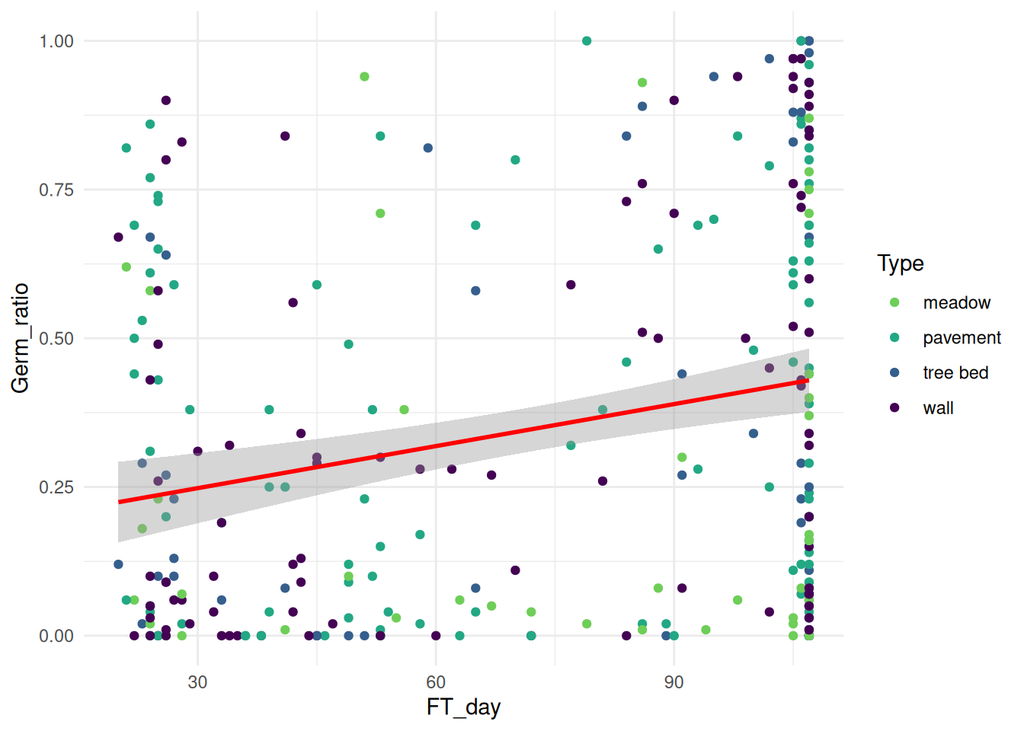

```r
ggplot(dormancy_ratio_FTexsitu, aes(x=FT_day, y=Germ_ratio, color=Type)) +
  geom_point() +
  geom_smooth(method=lm , color="red", se=TRUE) +
  scale_color_manual(values = colors) +
  theme_minimal()
```

Per habitats

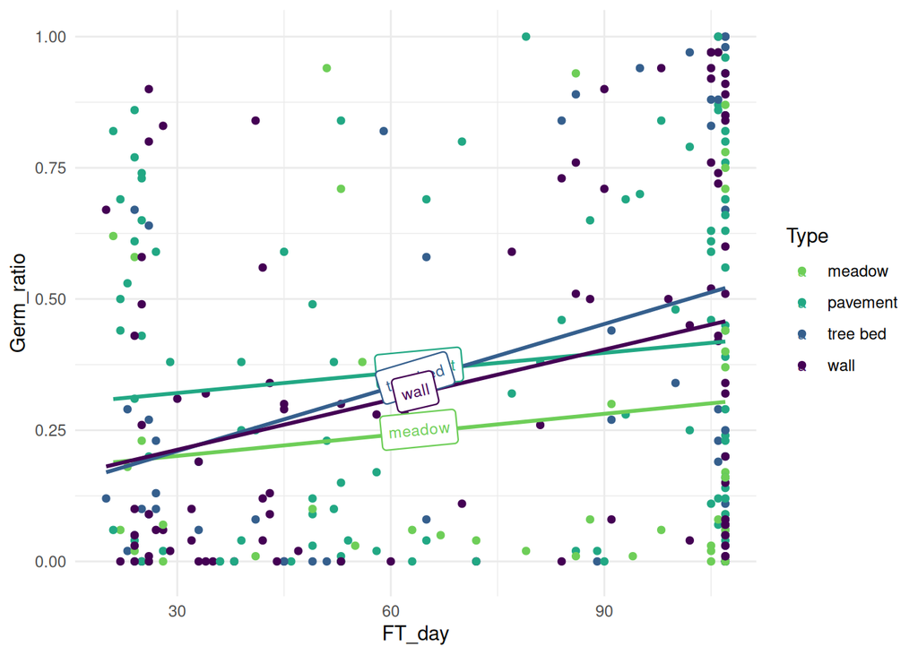

```r
ggplot(dormancy_ratio_FTexsitu, aes(x=FT_day, y=Germ_ratio, color=Type)) +
  geom_point() +
  geom_labelsmooth(aes(label = Type), fill = "white",
                   method = "lm", formula = y ~ x,
                   size = 3, linewidth = 1, boxlinewidth = 0.4) +
  scale_color_manual(values = colors) + theme_minimal()
```

Correlation test

```r
cor.test(dormancy_ratio_FTexsitu$Germ_ratio, dormancy_ratio_FTexsitu$FT_day,  method = "spearman")
```

```
##
##  Spearman's rank correlation rho
##
## data:  dormancy_ratio_FTexsitu$Germ_ratio and dormancy_ratio_FTexsitu$FT_day
## S = 3438869, p-value = 0.002014
## alternative hypothesis: true rho is not equal to 0
## sample estimates:
##       rho
## 0.1797069
```

```r
dormancy_ratio_FTexsitu |>
  group_by(Type) |>
  group_map(~ cor_test(.x, vars = Germ_ratio,vars2 = FT_day,  method = "spearman"))
```

```
## [[1]]
## # A tibble: 1 × 6
##   var1       var2     cor statistic     p method
##   <chr>      <chr>  <dbl>     <dbl> <dbl> <chr>
## 1 Germ_ratio FT_day  0.18    13301. 0.232 Spearman
##
## [[2]]
## # A tibble: 1 × 6
##   var1       var2     cor statistic     p method
##   <chr>      <chr>  <dbl>     <dbl> <dbl> <chr>
## 1 Germ_ratio FT_day  0.11   158138.  0.29 Spearman
##
## [[3]]
## # A tibble: 1 × 6
##   var1       var2     cor statistic      p method
##   <chr>      <chr>  <dbl>     <dbl>  <dbl> <chr>
## 1 Germ_ratio FT_day  0.26    13719. 0.0798 Spearman
##
## [[4]]
## # A tibble: 1 × 6
##   var1       var2     cor statistic      p method
##   <chr>      <chr>  <dbl>     <dbl>  <dbl> <chr>
## 1 Germ_ratio FT_day  0.24   115864. 0.0188 Spearman
```

Correlation test per type of habitat, only the wall is significant

```r
glm_model <- glmmTMB(FT_day ~ Germ_ratio*Type, data  = dormancy_ratio_FTexsitu, family = nbinom2())
summary(glm_model)
```

```
##  Family: nbinom2  ( log )
## Formula:          FT_day ~ Germ_ratio * Type
## Data: dormancy_ratio_FTexsitu
##
##       AIC       BIC    logLik -2*log(L)  df.resid
##    2910.2    2943.3   -1446.1    2892.2       284
##
##
## Dispersion parameter for nbinom2 family (): 3.97
##
## Conditional model:
##                         Estimate Std. Error z value Pr(>|z|)
## (Intercept)              4.29284    0.09894   43.39   <2e-16 ***
## Germ_ratio               0.17955    0.23993    0.75   0.4543
## Typepavement            -0.10289    0.12677   -0.81   0.4170
## Typetree bed            -0.17838    0.14686   -1.21   0.2245
## Typewall                -0.22557    0.12400   -1.82   0.0689 .
## Germ_ratio:Typepavement  0.02049    0.28941    0.07   0.9436
## Germ_ratio:Typetree bed  0.28466    0.31307    0.91   0.3632
## Germ_ratio:Typewall      0.28255    0.28661    0.99   0.3242
## ---
## Signif. codes:  0 '***' 0.001 '**' 0.01 '*' 0.05 '.' 0.1 ' ' 1
```

```r
Anova(glm_model, type='II')
```

```
## Analysis of Deviance Table (Type II Wald chisquare tests)
##
## Response: FT_day
##                   Chisq Df Pr(>Chisq)
## Germ_ratio      13.9219  1  0.0001906 ***
## Type             2.4428  3  0.4857218
## Germ_ratio:Type  2.1832  3  0.5352641
## ---
## Signif. codes:  0 '***' 0.001 '**' 0.01 '*' 0.05 '.' 0.1 ' ' 1
```

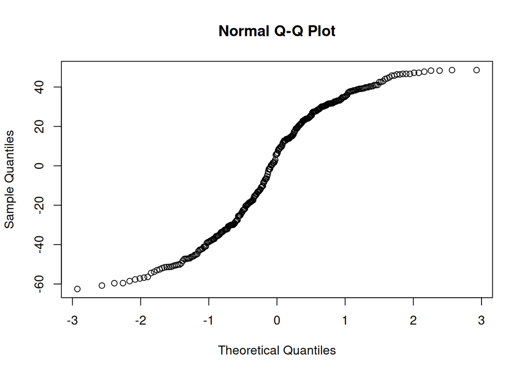

```r
qqnorm(resid(glm_model))
```

## 2. Using estimate of the models for correlation

FT ex situ model

```r
mod_FT <- glmmTMB(
  FT_day ~ Pop/Individual + Tray ,   # Pop nested in Type
  data   = data_FT_F6,
  family = nbinom2)
#summary(mod_FT)
```

Keep the estimate per individual

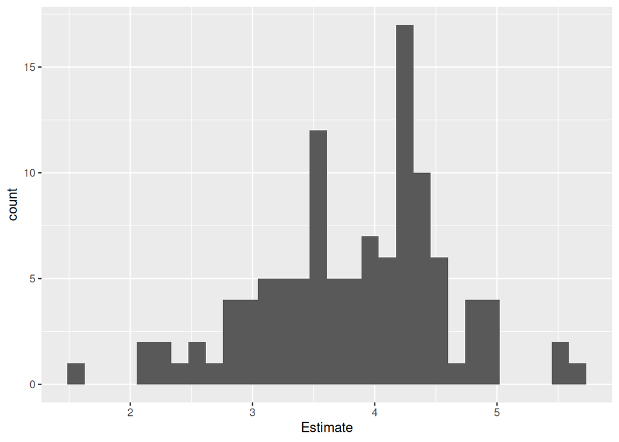

```r
estimate_mod_FT <- summary(mod_FT)[["coefficients"]][["cond"]]
estimate_mod_FT <- data.frame(estimate_mod_FT)

estimate_mod_FT$Pop <- rownames(estimate_mod_FT)
estimate_mod_FT[1,5] <- "Pop1"
estimate_mod_FT <- subset(estimate_mod_FT, grepl("Pop", Pop) & !grepl("Ind", Pop))
estimate_mod_FT <- estimate_mod_FT %>% separate_wider_delim(Pop, "p", names = c("Toremove", "ID_pop"))
estimate_mod_FT <- estimate_mod_FT[,-c(5)]
estimate_mod_FT$Estimate <-as.numeric(estimate_mod_FT$Estimate )

test <- estimate_mod_FT[2:112,] %>% rowwise() %>% mutate(Estimate = Estimate + estimate_mod_FT[1,1])
test$Estimate <- test$Estimate$Estimate
estimate_mod_FT <- rbind(estimate_mod_FT[1,], test)
estimate_mod_FT$Estimate <- as.numeric(estimate_mod_FT$Estimate)
ggplot(estimate_mod_FT, aes(x = Estimate)) + geom_histogram()
```

Dormancy situ model

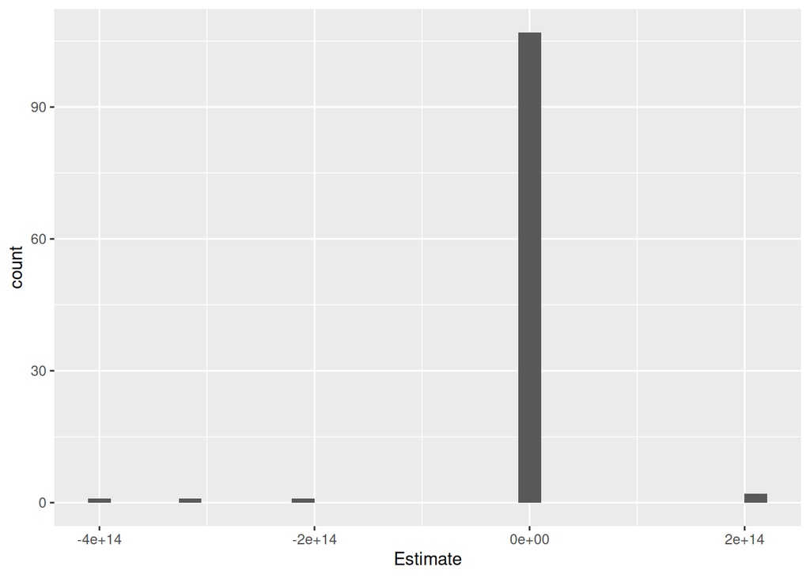

```r
dormancy_data <- dormancy_data %>% filter(seed_count_total >1)

# mod_dormancy <- glm(formula = cbind(seed_count_germinated, seed_count_total - seed_count_germinated) ~ Week_afterbagging + ID_pop/ID_pop_indv,
#                     family = quasibinomial(), data = dormancy_data)
# #summary(mod_dormancy)
#
# #+ message=FALSE, warning=FALSE
# estimate_mod_dormancy <- summary(mod_dormancy)[["coefficients"]]
# estimate_mod_dormancy <- data.frame(estimate_mod_dormancy)
#
# estimate_mod_dormancy$Pop <- rownames(estimate_mod_dormancy)
# estimate_mod_dormancy[1,5] <- "pop1"
# estimate_mod_dormancy <- subset(estimate_mod_dormancy, grepl("pop", Pop) & !grepl("ind", Pop))
# estimate_mod_dormancy <- estimate_mod_dormancy %>% separate_wider_delim(Pop, "pop", names = c("Toremove", "ID_pop"))
# estimate_mod_dormancy <- estimate_mod_dormancy[,-c(5)]
#
# test <- estimate_mod_dormancy[2:112,] %>% rowwise() %>% mutate(Estimate = Estimate + estimate_mod_dormancy[1,1])
# test$Estimate <- test$Estimate$Estimate
# estimate_mod_dormancy <- rbind(estimate_mod_dormancy[1,], test)
# estimate_mod_dormancy$Estimate <- as.numeric(estimate_mod_dormancy$Estimate)
# write.csv(estimate_mod_dormancy, "/home/justine/sciebo - Floret, Justine (jfloret@uni-koeln.de)@uni-koeln.sciebo.de/3_Exsitu_phenotype/Dormancy/2_assays/estimate_mod_dormancy.csv")

estimate_mod_dormancy <- read_csv("/home/justine/sciebo/3_Exsitu_phenotype/Dormancy/2_assays/estimate_mod_dormancy.csv")

ggplot(estimate_mod_dormancy, aes(x = Estimate)) + geom_histogram()
```

Filtering out extreme value

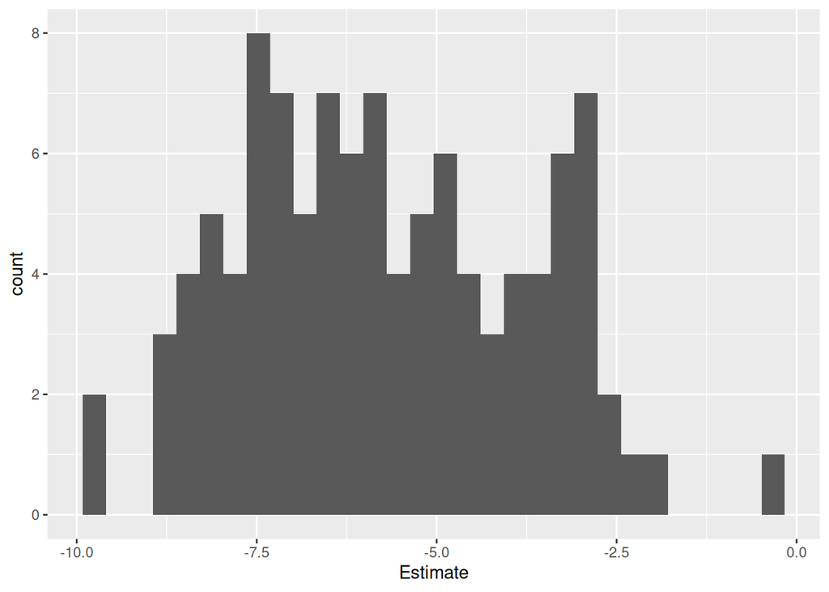

```r
estimate_mod_dormancy <- estimate_mod_dormancy %>% filter(Estimate < 10 & Estimate > -10)
ggplot(estimate_mod_dormancy, aes(x = Estimate)) + geom_histogram()
```

Merging the data set

```r
estimate_mod <- merge(estimate_mod_dormancy[,c(2,6)], estimate_mod_FT[,c(1,5)], by.x= c("ID_pop"), by.y = c("ID_pop") )
colnames(estimate_mod) <- c("ID_pop", "Estimate_dormancy", "Estimate_FT")
```

Adding the type

```r
estimate_mod <- merge(estimate_mod, data_FT_F6[,c(1,12)], by.x= c("ID_pop"), by.y = c("Pop") )
estimate_mod <- estimate_mod %>% distinct(ID_pop, .keep_all = TRUE)
```

### All habitats

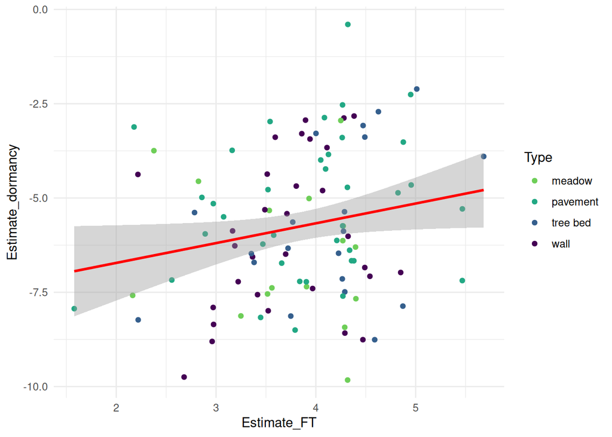

```r
ggplot(estimate_mod, aes(x=Estimate_FT, y=Estimate_dormancy, color=Type)) +
  geom_point() +
  geom_smooth(method=lm , color="red", se=TRUE) +
  scale_color_manual(values = colors) +
  theme_minimal()
```

### Per habitats

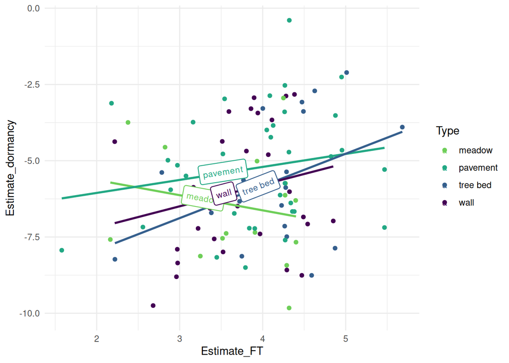

```r
ggplot(estimate_mod, aes(x=Estimate_FT, y=Estimate_dormancy, color=Type)) +
  geom_point() +
  geom_labelsmooth(aes(label = Type), fill = "white",
                   method = "lm", formula = y ~ x,
                   size = 3, linewidth = 1, boxlinewidth = 0.4) +
  scale_color_manual(values = colors) + theme_minimal()
```

Correlation test

```r
cor.test(estimate_mod$Estimate_dormancy, estimate_mod$Estimate_FT,  method = "spearman")
```

```
##
##  Spearman's rank correlation rho
##
## data:  estimate_mod$Estimate_dormancy and estimate_mod$Estimate_FT
## S = 154142, p-value = 0.07113
## alternative hypothesis: true rho is not equal to 0
## sample estimates:
##       rho
## 0.1777339
```

Correlation test with all type of habitats is not significant

```r
estimate_mod |>
  group_by(Type) |>
  group_map(~ cor_test(.x, vars = Estimate_dormancy,vars2 = Estimate_FT,  method = "spearman"))
```

```
## [[1]]
## # A tibble: 1 × 6
##   var1              var2          cor statistic     p method
##   <chr>             <chr>       <dbl>     <dbl> <dbl> <chr>
## 1 Estimate_dormancy Estimate_FT -0.28       868 0.299 Spearman
##
## [[2]]
## # A tibble: 1 × 6
##   var1              var2          cor statistic     p method
##   <chr>             <chr>       <dbl>     <dbl> <dbl> <chr>
## 1 Estimate_dormancy Estimate_FT  0.18      6956 0.298 Spearman
##
## [[3]]
## # A tibble: 1 × 6
##   var1              var2          cor statistic     p method
##   <chr>             <chr>       <dbl>     <dbl> <dbl> <chr>
## 1 Estimate_dormancy Estimate_FT  0.36       848 0.117 Spearman
##
## [[4]]
## # A tibble: 1 × 6
##   var1              var2          cor statistic     p method
##   <chr>             <chr>       <dbl>     <dbl> <dbl> <chr>
## 1 Estimate_dormancy Estimate_FT  0.24      3792 0.201 Spearman
```

Correlation test per type of habitats is not significant

```r
estimate_mod$Estimate_dormancy <- as.numeric(estimate_mod$Estimate_dormancy)
estimate_mod$Estimate_FT <- as.numeric(estimate_mod$Estimate_FT)
estimate_mod$Type <- as.factor(estimate_mod$Type)
```

### GLM mdel

```r
glm_model <- glmmTMB(Estimate_FT ~ Estimate_dormancy, data  = estimate_mod)
summary(glm_model)
```

```
##  Family: gaussian  ( identity )
## Formula:          Estimate_FT ~ Estimate_dormancy
## Data: estimate_mod
##
##       AIC       BIC    logLik -2*log(L)  df.resid
##     237.8     245.7    -115.9     231.8       101
##
##
## Dispersion estimate for gaussian family (sigma^2): 0.544
##
## Conditional model:
##                   Estimate Std. Error z value Pr(>|z|)
## (Intercept)        4.29463    0.22436  19.142   <2e-16 ***
## Estimate_dormancy  0.07762    0.03693   2.101   0.0356 *
## ---
## Signif. codes:  0 '***' 0.001 '**' 0.01 '*' 0.05 '.' 0.1 ' ' 1
```

```r
Anova(glm_model, type='II')
```

```
## Analysis of Deviance Table (Type II Wald chisquare tests)
##
## Response: Estimate_FT
##                    Chisq Df Pr(>Chisq)
## Estimate_dormancy 4.4162  1     0.0356 *
## ---
## Signif. codes:  0 '***' 0.001 '**' 0.01 '*' 0.05 '.' 0.1 ' ' 1
```

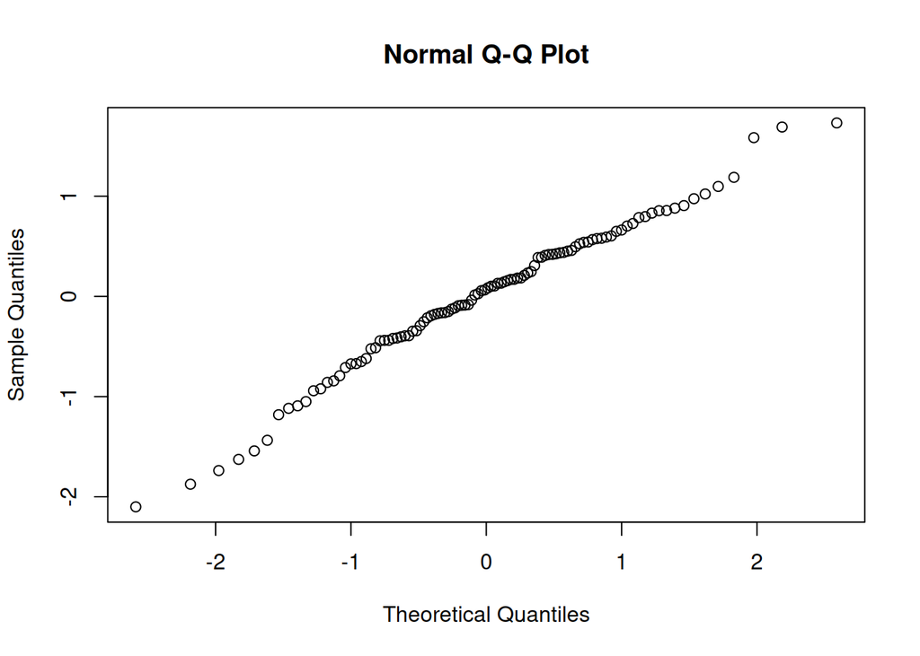

```r
qqnorm(resid(glm_model))
```

```r
glm_model <- glmmTMB(Estimate_FT ~ Estimate_dormancy*Type:ID_pop, data  = estimate_mod, family = Gamma(link="log"))
summary(glm_model)
```

```
##  Family: Gamma  ( log )
## Formula:          Estimate_FT ~ Estimate_dormancy * Type:ID_pop
## Data: estimate_mod
##
##       AIC       BIC    logLik -2*log(L)  df.resid
##     258.7     287.8    -118.3     236.7        93
##
##
## Dispersion estimate for Gamma family (sigma^2): 0.0397
##
## Conditional model:
##                                         Estimate Std. Error z value Pr(>|z|)
## (Intercept)                            1.393e+00  1.513e-01   9.210   <2e-16
## Estimate_dormancy                      1.748e-02  2.391e-02   0.731    0.465
## Typemeadow:ID_pop                     -1.708e-04  6.695e-04  -0.255    0.799
## Typepavement:ID_pop                    3.090e-04  5.141e-04   0.601    0.548
## Typetree bed:ID_pop                    1.106e-03  9.987e-04   1.108    0.268
## Typewall:ID_pop                       -4.041e-05  4.490e-04  -0.090    0.928
## Estimate_dormancy:Typemeadow:ID_pop   -6.438e-05  1.026e-04  -0.627    0.530
## Estimate_dormancy:Typepavement:ID_pop  2.912e-05  8.466e-05   0.344    0.731
## Estimate_dormancy:Typetree bed:ID_pop  9.977e-05  1.526e-04   0.654    0.513
## Estimate_dormancy:Typewall:ID_pop     -1.499e-05  7.318e-05  -0.205    0.838
##
## (Intercept)                           ***
## Estimate_dormancy
## Typemeadow:ID_pop
## Typepavement:ID_pop
## Typetree bed:ID_pop
## Typewall:ID_pop
## Estimate_dormancy:Typemeadow:ID_pop
## Estimate_dormancy:Typepavement:ID_pop
## Estimate_dormancy:Typetree bed:ID_pop
## Estimate_dormancy:Typewall:ID_pop
## ---
## Signif. codes:  0 '***' 0.001 '**' 0.01 '*' 0.05 '.' 0.1 ' ' 1
```

```r
Anova(glm_model, type='II')
```

```
## Analysis of Deviance Table (Type II Wald chisquare tests)
##
## Response: Estimate_FT
##                                Chisq Df Pr(>Chisq)
## Estimate_dormancy             4.1662  1    0.04124 *
## Type:ID_pop                   3.7940  4    0.43461
## Estimate_dormancy:Type:ID_pop 1.8070  4    0.77120
## ---
## Signif. codes:  0 '***' 0.001 '**' 0.01 '*' 0.05 '.' 0.1 ' ' 1
```

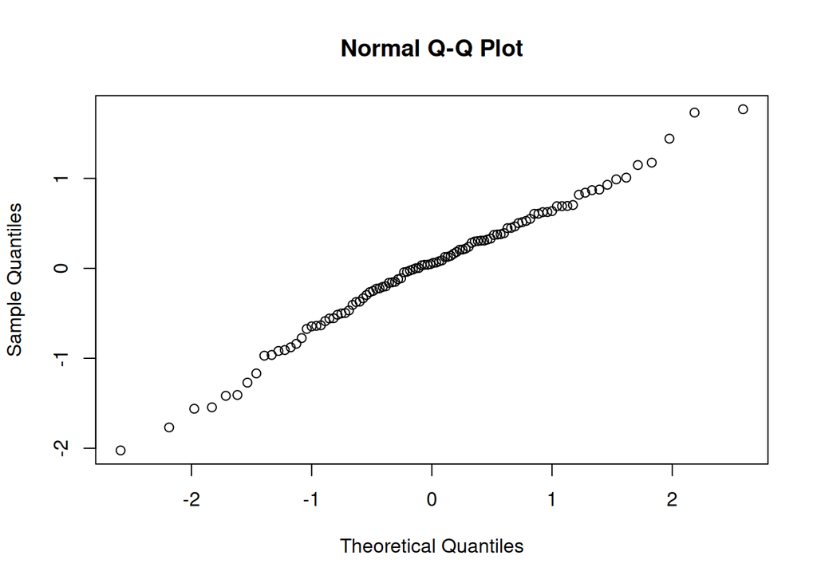

```r
qqnorm(resid(glm_model))
```

```r
glm_model <- glmmTMB(Estimate_FT ~ Estimate_dormancy + (1 | Type/ID_pop),
                     data = estimate_mod,
                     family = Gamma(link = "log"))
summary(glm_model)
```

```
##  Family: Gamma  ( log )
## Formula:          Estimate_FT ~ Estimate_dormancy + (1 | Type/ID_pop)
## Data: estimate_mod
##
##       AIC       BIC    logLik -2*log(L)  df.resid
##     252.2     265.4    -121.1     242.2        99
##
## Random effects:
##
## Conditional model:
##  Groups      Name        Variance  Std.Dev.
##  ID_pop:Type (Intercept) 5.801e-11 7.616e-06
##  Type        (Intercept) 1.261e-11 3.551e-06
## Number of obs: 104, groups:  ID_pop:Type, 104; Type, 4
##
## Dispersion estimate for Gamma family (sigma^2): 0.0418
##
## Conditional model:
##                   Estimate Std. Error z value Pr(>|z|)
## (Intercept)        1.46111    0.06190  23.603   <2e-16 ***
## Estimate_dormancy  0.01987    0.01018   1.951   0.0511 .
## ---
## Signif. codes:  0 '***' 0.001 '**' 0.01 '*' 0.05 '.' 0.1 ' ' 1
```

```r
Anova(glm_model, type='II')
```

```
## Analysis of Deviance Table (Type II Wald chisquare tests)
##
## Response: Estimate_FT
##                    Chisq Df Pr(>Chisq)
## Estimate_dormancy 3.8053  1    0.05109 .
## ---
## Signif. codes:  0 '***' 0.001 '**' 0.01 '*' 0.05 '.' 0.1 ' ' 1
```

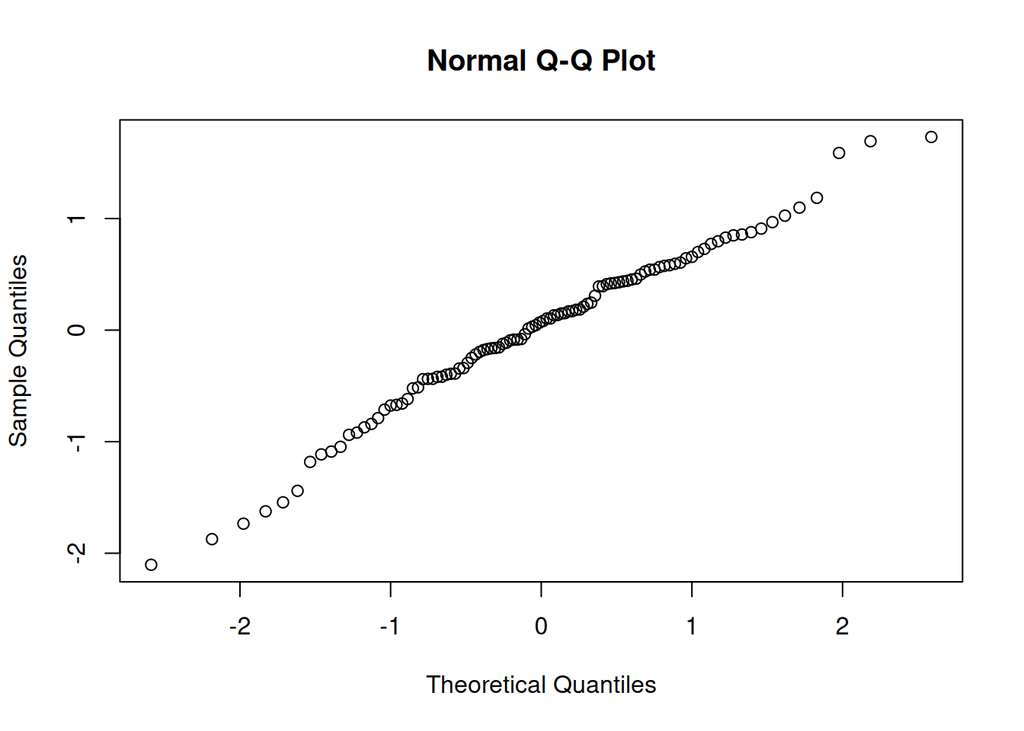

```r
qqnorm(resid(glm_model))
```

```r
glm_model <- glmmTMB(Estimate_FT ~ Estimate_dormancy+Type/ID_pop, data  = estimate_mod, family = Gamma(link="log"))
summary(glm_model)
```

```
##  Family: Gamma  ( log )
## Formula:          Estimate_FT ~ Estimate_dormancy + Type/ID_pop
## Data: estimate_mod
##
##       AIC       BIC    logLik -2*log(L)  df.resid
##     254.1     280.6    -117.1     234.1        94
##
##
## Dispersion estimate for Gamma family (sigma^2): 0.0387
##
## Conditional model:
##                       Estimate Std. Error z value Pr(>|z|)
## (Intercept)          1.259e+00  1.096e-01  11.489   <2e-16 ***
## Estimate_dormancy    1.716e-02  1.035e-02   1.659   0.0972 .
## Typepavement         1.812e-01  1.169e-01   1.550   0.1212
## Typetree bed         4.063e-01  2.224e-01   1.827   0.0676 .
## Typewall             1.566e-01  1.146e-01   1.367   0.1717
## Typemeadow:ID_pop    5.810e-04  2.626e-04   2.213   0.0269 *
## Typepavement:ID_pop  2.405e-05  2.256e-04   0.107   0.9151
## Typetree bed:ID_pop -7.613e-04  9.521e-04  -0.800   0.4240
## Typewall:ID_pop     -7.838e-06  1.847e-04  -0.042   0.9662
## ---
## Signif. codes:  0 '***' 0.001 '**' 0.01 '*' 0.05 '.' 0.1 ' ' 1
```

```r
Anova(glm_model, type='II')
```

```
## Analysis of Deviance Table (Type II Wald chisquare tests)
##
## Response: Estimate_FT
##                    Chisq Df Pr(>Chisq)
## Estimate_dormancy 2.7513  1    0.09718 .
## Type              3.0182  3    0.38883
## Type:ID_pop       5.5792  4    0.23285
## ---
## Signif. codes:  0 '***' 0.001 '**' 0.01 '*' 0.05 '.' 0.1 ' ' 1
```

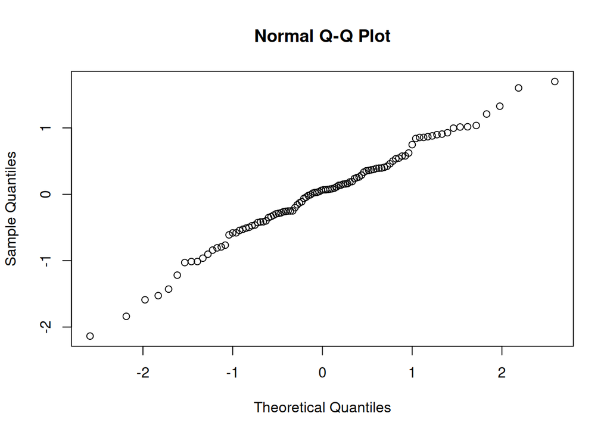

```r
qqnorm(resid(glm_model))
```

## 3. Graphic with both plot

estimated data

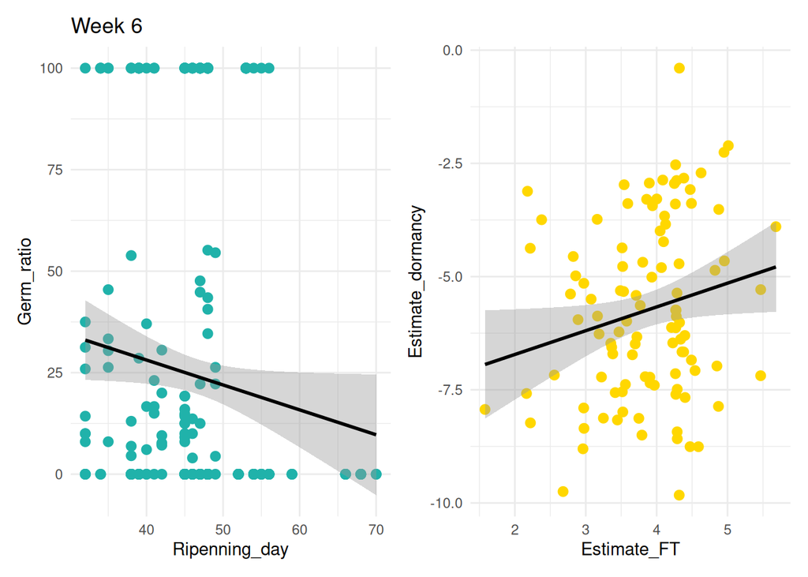

```r
g1 <- ggplot(estimate_mod, aes(x=Estimate_FT, y=Estimate_dormancy)) +
  geom_point(size = 2.5, color="#FFD700") +
  geom_smooth(method=lm , color="black", se=TRUE) +
  scale_color_manual(values = colors) +
  theme_minimal()

g2 <- F2_dormancy_df %>% filter(Week == 6) %>%
  ggplot(aes(x=Ripenning_day, y=Germ_ratio)) +
  geom_point(size = 2.5, color="#20B2AA") +
  geom_smooth(method=lm , color="black", se=TRUE) +
  labs(title = "Week 6")+
  theme_minimal()

g2 + g1 +
  plot_layout(ncol = 2, guides = "collect")
```

Observed data

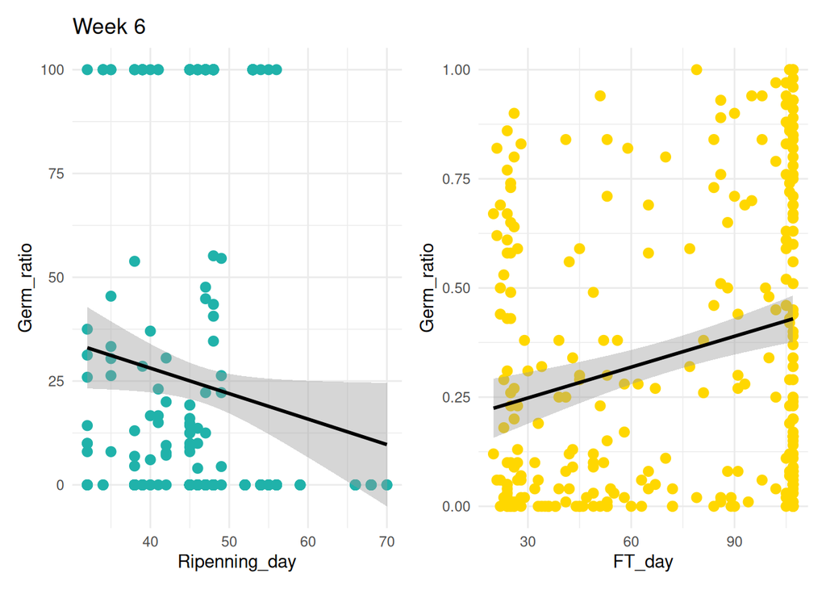

```r
g3 <- ggplot(dormancy_ratio_FTexsitu, aes(x=FT_day, y=Germ_ratio, color=Type)) +
  geom_point(size = 2.5, color="#FFD700") +
  geom_smooth(method=lm , color="black", se=TRUE) +
  scale_color_manual(values = colors) +
  theme_minimal()

g2 + g3 +
  plot_layout(ncol = 2, guides = "collect")
```

Combine bith data set to create one graph

```r
F2_dormancy_df %>% filter(Week == 6) %>% distinct(Plant_ID) %>% count()
```

```
## # A tibble: 1 × 1
##       n
##   <int>
## 1   334
```

```r
dormancy_ratio_FTexsitu %>% group_by(ID_pop)%>% count() %>% distinct()
```

```
## # A tibble: 109 × 2
## # Groups:   ID_pop [109]
##    ID_pop     n
##    <fct>  <int>
##  1 1          4
##  2 102        3
##  3 104        2
##  4 105        4
##  5 106        2
##  6 113        2
##  7 114        2
##  8 120        3
##  9 122        2
## 10 156        1
## # ℹ 99 more rows
```

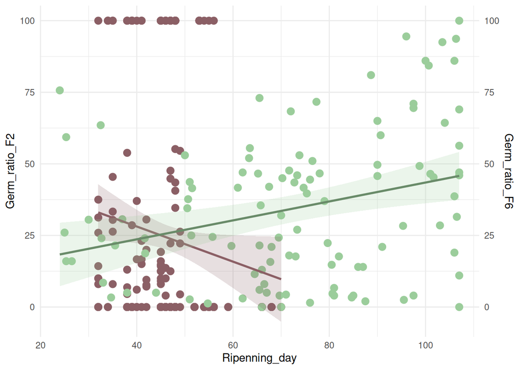

```r
combined_dataset <- F2_dormancy_df %>% filter(Week == 6)
combined_dataset <- combined_dataset[,c(1,2,6)]
colnames(combined_dataset) <- c("Plant_ID", "Ripenning_day", "Germ_ratio_F2")
tmp <- dormancy_ratio_FTexsitu %>% group_by(ID_pop)%>% summarise(Germ_ratio_F6 = mean(Germ_ratio), FT_day = mean(FT_day))
combined_dataset <-cbindX(combined_dataset, tmp)
combined_dataset$Germ_ratio_F6 <- combined_dataset$Germ_ratio_F6*100

ggplot(combined_dataset) +
  geom_point( aes(x = Ripenning_day, y=Germ_ratio_F2), size=3, color="#8B5F65") +
  geom_point( aes(x =FT_day ,y=Germ_ratio_F6), size=3, color="#9BCD9B") +
  scale_y_continuous(name = "Germ_ratio_F2", sec.axis = sec_axis( trans=~. , name="Germ_ratio_F6")) +
  theme_minimal() +
  geom_smooth(aes(x= Ripenning_day, y= Germ_ratio_F2), color="#8B5F65", fill="#8B5F65", method=lm , se=TRUE, alpha = 0.2) +
  geom_smooth(aes(x= FT_day, y= Germ_ratio_F6), color="#698B69", fill="#9BCD9B", method=lm , se=TRUE, alpha = 0.2)
```

```r
c("#7C8F7D", "#FFFFFF", "#FFFFFF")
```

```
## [1] "#7C8F7D" "#FFFFFF" "#FFFFFF"
```

```r
c("#6E7B8B", "#87CEFA", "#7EC0EE", "#5CACEE", "#63B8FF", "#FFFFFF")
```

```
## [1] "#6E7B8B" "#87CEFA" "#7EC0EE" "#5CACEE" "#63B8FF" "#FFFFFF"
```

```r
c("#CDB7B5", "#8B5F65", "#9BCD9B", "#698B69", "#87CEFF", "#4A708B", "#FFFFFF")
```

```
## [1] "#CDB7B5" "#8B5F65" "#9BCD9B" "#698B69" "#87CEFF" "#4A708B" "#FFFFFF"
```

```r
c("#53868B", "#79CDCD", "#20B2AA", "#FFFFFF", "#FFFFFF")
```

```
## [1] "#53868B" "#79CDCD" "#20B2AA" "#FFFFFF" "#FFFFFF"
```

```r
c("#53868B", "#1E90FF", "#00CDCD", "#FFD700", "#FFFF00", "#FFDE24")
```

```
## [1] "#53868B" "#1E90FF" "#00CDCD" "#FFD700" "#FFFF00" "#FFDE24"
```